# Lab 6: Variable Selection and Regularization

Author

Karisa Kopecek

Published

November 9, 2025

# Cleaning data

```python
import numpy as np
import pandas as pd
from plotnine import *
from sklearn.linear_model import LinearRegression
from sklearn.preprocessing import OneHotEncoder
from sklearn.metrics import mean_squared_error, r2_score
from sklearn.pipeline import Pipeline
from sklearn.compose import make_column_selector, ColumnTransformer
from sklearn.preprocessing import StandardScaler, OneHotEncoder, PolynomialFeatures
from sklearn.linear_model import LinearRegression, Ridge, Lasso, ElasticNet
from sklearn.model_selection import train_test_split, cross_val_score, GridSearchCV
```

```python
data_dir = "Data/Hitters.csv"
df = pd.read_csv(data_dir)
df.head() #making sure code shows up
```

|  | AtBat | Hits | HmRun | Runs | RBI | Walks | Years | CAtBat | CHits | CHmRun | CRuns | CRBI | CWalks | League | Division | PutOuts | Assists | Errors | Salary | NewLeague |
| --- | --- | --- | --- | --- | --- | --- | --- | --- | --- | --- | --- | --- | --- | --- | --- | --- | --- | --- | --- | --- |
| 0 | 293 | 66 | 1 | 30 | 29 | 14 | 1 | 293 | 66 | 1 | 30 | 29 | 14 | A | E | 446 | 33 | 20 | NaN | A |
| 1 | 315 | 81 | 7 | 24 | 38 | 39 | 14 | 3449 | 835 | 69 | 321 | 414 | 375 | N | W | 632 | 43 | 10 | 475.0 | N |
| 2 | 479 | 130 | 18 | 66 | 72 | 76 | 3 | 1624 | 457 | 63 | 224 | 266 | 263 | A | W | 880 | 82 | 14 | 480.0 | A |
| 3 | 496 | 141 | 20 | 65 | 78 | 37 | 11 | 5628 | 1575 | 225 | 828 | 838 | 354 | N | E | 200 | 11 | 3 | 500.0 | N |
| 4 | 321 | 87 | 10 | 39 | 42 | 30 | 2 | 396 | 101 | 12 | 48 | 46 | 33 | N | E | 805 | 40 | 4 | 91.5 | N |

```python
df.info()
```

```
<class 'pandas.core.frame.DataFrame'>
RangeIndex: 322 entries, 0 to 321
Data columns (total 20 columns):
 #   Column     Non-Null Count  Dtype
---  ------     --------------  -----
 0   AtBat      322 non-null    int64
 1   Hits       322 non-null    int64
 2   HmRun      322 non-null    int64
 3   Runs       322 non-null    int64
 4   RBI        322 non-null    int64
 5   Walks      322 non-null    int64
 6   Years      322 non-null    int64
 7   CAtBat     322 non-null    int64
 8   CHits      322 non-null    int64
 9   CHmRun     322 non-null    int64
 10  CRuns      322 non-null    int64
 11  CRBI       322 non-null    int64
 12  CWalks     322 non-null    int64
 13  League     322 non-null    object
 14  Division   322 non-null    object
 15  PutOuts    322 non-null    int64
 16  Assists    322 non-null    int64
 17  Errors     322 non-null    int64
 18  Salary     263 non-null    float64
 19  NewLeague  322 non-null    object
dtypes: float64(1), int64(16), object(3)
memory usage: 50.4+ KB
```

```python
df.describe()
```

|  | AtBat | Hits | HmRun | Runs | RBI | Walks | Years | CAtBat | CHits | CHmRun | CRuns | CRBI | CWalks | PutOuts | Assists | Errors | Salary |
| --- | --- | --- | --- | --- | --- | --- | --- | --- | --- | --- | --- | --- | --- | --- | --- | --- | --- |
| count | 322.000000 | 322.000000 | 322.000000 | 322.000000 | 322.000000 | 322.000000 | 322.000000 | 322.00000 | 322.000000 | 322.000000 | 322.000000 | 322.000000 | 322.000000 | 322.000000 | 322.000000 | 322.000000 | 263.000000 |
| mean | 380.928571 | 101.024845 | 10.770186 | 50.909938 | 48.027950 | 38.742236 | 7.444099 | 2648.68323 | 717.571429 | 69.490683 | 358.795031 | 330.118012 | 260.239130 | 288.937888 | 106.913043 | 8.040373 | 535.925882 |
| std | 153.404981 | 46.454741 | 8.709037 | 26.024095 | 26.166895 | 21.639327 | 4.926087 | 2324.20587 | 654.472627 | 86.266061 | 334.105886 | 333.219617 | 267.058085 | 280.704614 | 136.854876 | 6.368359 | 451.118681 |
| min | 16.000000 | 1.000000 | 0.000000 | 0.000000 | 0.000000 | 0.000000 | 1.000000 | 19.00000 | 4.000000 | 0.000000 | 1.000000 | 0.000000 | 0.000000 | 0.000000 | 0.000000 | 0.000000 | 67.500000 |
| 25% | 255.250000 | 64.000000 | 4.000000 | 30.250000 | 28.000000 | 22.000000 | 4.000000 | 816.75000 | 209.000000 | 14.000000 | 100.250000 | 88.750000 | 67.250000 | 109.250000 | 7.000000 | 3.000000 | 190.000000 |
| 50% | 379.500000 | 96.000000 | 8.000000 | 48.000000 | 44.000000 | 35.000000 | 6.000000 | 1928.00000 | 508.000000 | 37.500000 | 247.000000 | 220.500000 | 170.500000 | 212.000000 | 39.500000 | 6.000000 | 425.000000 |
| 75% | 512.000000 | 137.000000 | 16.000000 | 69.000000 | 64.750000 | 53.000000 | 11.000000 | 3924.25000 | 1059.250000 | 90.000000 | 526.250000 | 426.250000 | 339.250000 | 325.000000 | 166.000000 | 11.000000 | 750.000000 |
| max | 687.000000 | 238.000000 | 40.000000 | 130.000000 | 121.000000 | 105.000000 | 24.000000 | 14053.00000 | 4256.000000 | 548.000000 | 2165.000000 | 1659.000000 | 1566.000000 | 1378.000000 | 492.000000 | 32.000000 | 2460.000000 |

```python
#see the duplicates in the dataset
df.duplicated().sum()
df[df.duplicated(keep=False)]
```

|  | AtBat | Hits | HmRun | Runs | RBI | Walks | Years | CAtBat | CHits | CHmRun | CRuns | CRBI | CWalks | League | Division | PutOuts | Assists | Errors | Salary | NewLeague |
| --- | --- | --- | --- | --- | --- | --- | --- | --- | --- | --- | --- | --- | --- | --- | --- | --- | --- | --- | --- | --- |

removed duplicates

```python
#drop those duplicates
df = df.drop_duplicates()
```

```python
#missing values sum
df.isnull().sum()
```

```
AtBat         0
Hits          0
HmRun         0
Runs          0
RBI           0
Walks         0
Years         0
CAtBat        0
CHits         0
CHmRun        0
CRuns         0
CRBI          0
CWalks        0
League        0
Division      0
PutOuts       0
Assists       0
Errors        0
Salary       59
NewLeague     0
dtype: int64
```

removed rows missing salary

```python
#remove rows with missing salary
df = df.dropna(subset=['Salary'])
#check that it worked, ran this earlier when working
#df.isnull().sum()
```

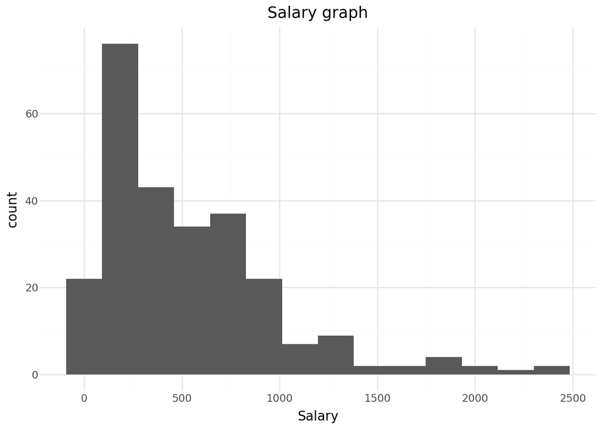

```python
#making a plot of my target vairable to check for outliers, so that I can fix it if that is an issue
(ggplot(df, aes(x='Salary')) +
 geom_histogram() +
 labs(title='Salary graph', x='Salary') +
 theme_minimal())
```

Removed salaries past 2000 because those were outliers and seemed unreliable

```python
#Removing outliers past 2000 based on histogram from before (felt like salaries past that were outliers and unreliable)
df = df[df['Salary'] < 2000]
```

```python
#all columns except salary
X = df.drop(["Salary"], axis=1)
#the salary column
y = df["Salary"]
```

```python
#column transformer setup based on instructions/helpful notes

#dummify is applying one-hot encoding to all object type columns from above (sparse_output=False returns a regular array and handle_unknown='ignore' ignores categories not seen during training
ct = ColumnTransformer(
    [("dummify", OneHotEncoder(sparse_output=False, handle_unknown='ignore'),
         make_column_selector(dtype_include=object)),
        ("standardize", StandardScaler(), #Applies standard scaling (mean = 0 and st. dev = 1) to all numeric columns from above
         make_column_selector(dtype_include=np.number)) #picks out all the numeric columns
    ],
    remainder="passthrough" #If there are any columns not selected by either transformer, they’re passed through unchanged not dropped
)
```

# Part 1: Different Model Specs

## a. regression without regularization

Create a pipeline that includes all the columns as predictors for Salary, and performs ordinary linear regression

```python
#two step pipeline, fits the column tranformer from above and then runs linear regression
lr_pipeline = Pipeline(
    [("preprocessing", ct),
     ("linear_regression", LinearRegression())]
)
```

Fit this pipeline to the full dataset, and interpret a few of the most important coefficients.

```python
#passing the right columns to the pipline and fitting pipline to all the data
lr_fitted = lr_pipeline.fit(X, y)

#coefficients for interpretation
#get_feature_names_out() returns the names of all transformed features like all the dummy variables
feature_names = lr_fitted.named_steps['preprocessing'].get_feature_names_out()
lr_coef = lr_fitted.named_steps['linear_regression'].coef_ #gives the weights, how much each coef predicts salary

#pairing the above together in a series to get which features have the biggest positive or negative effects on the target
the_series = pd.Series(lr_coef, index=feature_names)

# Sort by absolute value (most to least important)
series_sorted = the_series.sort_values(key=abs, ascending=False)

series_sorted
```

```
standardize__CRuns      453.804254
standardize__Hits       276.334352
standardize__CRBI       267.974955
standardize__CAtBat    -204.576219
standardize__AtBat     -190.748646
standardize__CWalks    -179.888029
standardize__Walks      123.263086
standardize__CHits     -100.865589
standardize__CHmRun     -90.246206
standardize__PutOuts     67.481805
standardize__HmRun       56.769385
standardize__Runs       -50.730717
dummify__Division_W     -44.769267
dummify__Division_E      44.769267
standardize__RBI        -39.755308
dummify__League_A       -38.895250
dummify__League_N        38.895250
standardize__Assists     26.565949
standardize__Years       21.777354
standardize__Errors     -19.584540
dummify__NewLeague_N    -17.866127
dummify__NewLeague_A     17.866127
dtype: float64
```

The largest coefficient is for Career Runs (CRuns) which is therefore the most important in predicting salary. This is the largest positive coefficient which indicates that players who have scored more career runs tend to earn higher salaries.

The next most influential variable (Hits) also has a strong positive relationship with salary, showing that players who get more hits are paid higher. Similarly, Career RBIs (CRBI) positively affect salary (driving in runs over a career also boosts compensation).

In contrast, Career At Bats (CAtBat) and At Bat (AtBat) both have large negative coefficients, implying that having more at bats is associated with lower salaries. Basically, just having a lot of playing time isn’t good unless you are making good plays/hits etc.

Use cross-validation to estimate the MSE you would expect if you used this pipeline to predict 1989 salaries.

```python
# Cross-validate for MSE

# Run 5-fold cross-validation
my_mse_scores = -cross_val_score(lr_pipeline, X, y,
    cv=5,
    scoring='neg_mean_squared_error'
)

#the average/expected MSE across folds
expected_mse = np.mean(my_mse_scores)
expected_mse
```

```
np.float64(99398.6584056369)
```

## b. ridge regression

Create a pipeline that includes all the columns as predictors for Salary, and performs ordinary ridge regression

```python
ridge_pipeline = Pipeline(
    [("preprocessing", ct),
     ("ridge_regression", Ridge())]
)
```

Use cross-validation to tune the (regularization) hyperparameter. Fit the pipeline with your chosen parameter to the full dataset, and interpret a few of the most important coefficients.

```python
# Tune hyperparameter
# possible alpha values
alphas = {'ridge_regression__alpha': np.array([100, 10, 1, 0.1, 0.01])}

# Takes pipeline, runs 5-fold CV for each alpha, gets MSE, finds alpha that performs best
ridge_grid = GridSearchCV(ridge_pipeline, param_grid=alphas, cv=5, scoring='neg_mean_squared_error')
ridge_fitted = ridge_grid.fit(X, y)

# Get the best Ridge model
best_ridge = ridge_fitted.best_estimator_

# Get feature names from preprocessing
feature_names = best_ridge.named_steps['preprocessing'].get_feature_names_out()

# Get coefficients from the Ridge model
ridge_coef = best_ridge.named_steps['ridge_regression'].coef_

# Pair them into a Series for interpretation
the_series = pd.Series(ridge_coef, index=feature_names)

# Sort by absolute value (most to least important)
series_sorted2 = the_series.sort_values(key=abs, ascending=False)

series_sorted2
```

```
standardize__PutOuts    48.652982
standardize__Hits       47.418591
standardize__Walks      42.161681
standardize__CHits      41.603373
standardize__CRuns      41.458775
standardize__Runs       34.645697
standardize__CRBI       33.790039
standardize__CAtBat     28.307364
dummify__Division_E     27.436505
dummify__Division_W    -27.436505
standardize__RBI        19.205112
standardize__CHmRun     15.534506
standardize__Years      14.755449
standardize__Errors    -14.551143
standardize__AtBat      13.109067
dummify__League_A      -12.532370
dummify__League_N       12.532370
standardize__CWalks      9.587299
standardize__HmRun       5.785503
dummify__NewLeague_N     4.283496
dummify__NewLeague_A    -4.283496
standardize__Assists     1.155466
dtype: float64
```

The most important predictor of salary for this model is PutOuts, indicating that players who record more outs tend to earn higher salaries. Hits is the next most important and has a large positive coefficient, showing that players who get more hits are paid more. Walks also positively influences salary, so players who are good at getting on base are rewarded. Career Hits (CHits) and Career Runs (CRuns) also both have strong positive effects, showing that overall for the top influencial variables preforming well on offense and defence is a good predictor or salary. This model overall is making the coefficients smaller.

Report the MSE you would expect if you used this pipeline to predict 1989 salaries.

```python
ridge_cv_scores = cross_val_score(
    ridge_pipeline,  # your Ridge pipeline
    X,
    y,
    cv=5,
    scoring='neg_mean_squared_error'
)

mse_scores = -ridge_cv_scores

#expected/mean MSE
expected_mse = np.mean(mse_scores)
expected_mse
```

```
np.float64(95986.30641275103)
```

## c. lasso regression

Create a pipeline that includes all the columns as predictors for Salary, and performs ordinary ridge regression

```python
lasso_pipeline = Pipeline(
    [("preprocessing", ct),
     ("lasso_regression", Lasso())]
)
```

Use cross-validation to tune the (regularization) hyperparameter. Fit the pipeline with your chosen parameter to the full dataset, and interpret a few of the most important coefficients.

```python
alphas = {'lasso_regression__alpha': np.array([100, 10, 1, 0.1, 0.01])}
lasso_grid = GridSearchCV(lasso_pipeline, param_grid=alphas, cv=5, scoring='neg_mean_squared_error')
lasso_fitted = lasso_grid.fit(X, y)

# Best pipeline and its alpha
best_lasso = lasso_fitted.best_estimator_
best_alpha = lasso_fitted.best_params_['lasso_regression__alpha']

# Feature names and coefficients
feature_names = best_lasso.named_steps['preprocessing'].get_feature_names_out()
lasso_coef = best_lasso.named_steps['lasso_regression'].coef_

#Pair them into a series for interpretation
# Sort by absolute value (most to least important)
the_series = pd.Series(lasso_coef, index=feature_names)
series_sorted3 = the_series.sort_values(key=abs, ascending=False)

series_sorted3
```

```
standardize__CRuns      9.914383e+01
standardize__Hits       9.744695e+01
standardize__CRBI       6.420680e+01
standardize__PutOuts    5.827957e+01
dummify__Division_E     5.764193e+01
standardize__Walks      5.607900e+01
standardize__CHits      2.469668e+01
standardize__Errors    -1.017346e+01
dummify__League_A      -1.163783e+00
standardize__HmRun      1.081527e+00
dummify__Division_W    -2.044801e-12
dummify__League_N       7.016457e-15
dummify__NewLeague_N    0.000000e+00
dummify__NewLeague_A   -0.000000e+00
standardize__CAtBat     0.000000e+00
standardize__Years      0.000000e+00
standardize__RBI        0.000000e+00
standardize__Runs       0.000000e+00
standardize__AtBat     -0.000000e+00
standardize__CHmRun     0.000000e+00
standardize__CWalks    -0.000000e+00
standardize__Assists   -0.000000e+00
dtype: float64
```

The largest coefficient is for Career Runs (CRuns) which is therefore the most important in predicting salary. This is the largest positive coefficient which indicates that players who have scored more career runs tend to earn higher salaries. Hits and Career RBIs (CRBI) also have large positive coefficients, suggesting that consistent hitters and players who make consistent runs are paid more. PutOuts also has a positive effect, so defensive contributions also influence salary in this model. Overall, the Lasso model emphasizes a small set of strong predictors with other coefficients being made into 0 effect on the model. This model overall is trying to use as few variables as possible.

Report the MSE you would expect if you used this pipeline to predict 1989 salaries.

```python
lasso_cv_scores = cross_val_score(
    lasso_pipeline,  # your full Lasso pipeline
    X,
    y,
    cv=5,
    scoring='neg_mean_squared_error'
)

mse_scores = -lasso_cv_scores

#expected/mean MSE
expected_mse = np.mean(mse_scores)
expected_mse
```

```
np.float64(96038.67903965258)
```

## d. elastic net

Create a pipeline that includes all the columns as predictors for Salary, and performs ordinary ridge regression

```python
elastic_pipeline = Pipeline(
    [("preprocessing", ct),
     ("elastic_net", ElasticNet())]
)
```

```python
param_grid = {
    "elastic_net__alpha": [1, 10, 100],
    "elastic_net__l1_ratio": np.arange(0.0, 1.2, 0.2),
}
elastic_grid = GridSearchCV(elastic_pipeline, param_grid=param_grid, cv=5, scoring='neg_mean_squared_error')
elastic_fitted = elastic_grid.fit(X, y)

# Get best Elastic Net model and coefficients
best_elastic = elastic_fitted.best_estimator_
elastic_coef = best_elastic.named_steps['elastic_net'].coef_

# Feature names after preprocessing
feature_names = best_elastic.named_steps['preprocessing'].get_feature_names_out()

# Pair into a Series and sort by absolute importance
the_series = pd.Series(elastic_coef, index=feature_names)
series_sorted4 = the_series.sort_values(key=abs, ascending=False)

series_sorted4
```

```
standardize__PutOuts    42.801988
standardize__Hits       41.081220
standardize__Walks      38.010276
standardize__CHits      36.982988
standardize__CRuns      36.941348
standardize__Runs       32.555264
standardize__CRBI       30.945936
standardize__CAtBat     27.883130
dummify__Division_E     22.017312
dummify__Division_W    -22.017280
standardize__RBI        20.348900
standardize__AtBat      18.073739
standardize__CHmRun     16.820981
standardize__Years      16.228736
standardize__CWalks     15.068089
standardize__Errors    -11.031098
dummify__League_N        9.569796
dummify__League_A       -9.569762
standardize__HmRun       7.743989
dummify__NewLeague_N     4.439276
dummify__NewLeague_A    -4.439239
standardize__Assists     0.220270
dtype: float64
```

Report the MSE you would expect if you used this pipeline to predict 1989 salaries.

```python
elastic_cv_scores = cross_val_score(
    elastic_pipeline,
    X,
    y,
    cv=5,
    scoring='neg_mean_squared_error'
)

mse_scores = -elastic_cv_scores

expected_mse = np.mean(mse_scores)
expected_mse
```

```
np.float64(90968.67411939632)
```

# Part 2: Variable Selection

```python
# creating a dataframe to compare coefficients more easily
coef_compare = pd.DataFrame({
    'Feature': feature_names,
    'lr': lr_coef,
    'ridge': ridge_coef,
    'lasso': lasso_coef,
    'elastic': elastic_coef
})

coef_compare
```

|  | Feature | lr | ridge | lasso | elastic |
| --- | --- | --- | --- | --- | --- |
| 0 | dummify__League_A | -38.895250 | -12.532370 | -1.163783e+00 | -9.569762 |
| 1 | dummify__League_N | 38.895250 | 12.532370 | 7.016457e-15 | 9.569796 |
| 2 | dummify__Division_E | 44.769267 | 27.436505 | 5.764193e+01 | 22.017312 |
| 3 | dummify__Division_W | -44.769267 | -27.436505 | -2.044801e-12 | -22.017280 |
| 4 | dummify__NewLeague_A | 17.866127 | -4.283496 | -0.000000e+00 | -4.439239 |
| 5 | dummify__NewLeague_N | -17.866127 | 4.283496 | 0.000000e+00 | 4.439276 |
| 6 | standardize__AtBat | -190.748646 | 13.109067 | -0.000000e+00 | 18.073739 |
| 7 | standardize__Hits | 276.334352 | 47.418591 | 9.744695e+01 | 41.081220 |
| 8 | standardize__HmRun | 56.769385 | 5.785503 | 1.081527e+00 | 7.743989 |
| 9 | standardize__Runs | -50.730717 | 34.645697 | 0.000000e+00 | 32.555264 |
| 10 | standardize__RBI | -39.755308 | 19.205112 | 0.000000e+00 | 20.348900 |
| 11 | standardize__Walks | 123.263086 | 42.161681 | 5.607900e+01 | 38.010276 |
| 12 | standardize__Years | 21.777354 | 14.755449 | 0.000000e+00 | 16.228736 |
| 13 | standardize__CAtBat | -204.576219 | 28.307364 | 0.000000e+00 | 27.883130 |
| 14 | standardize__CHits | -100.865589 | 41.603373 | 2.469668e+01 | 36.982988 |
| 15 | standardize__CHmRun | -90.246206 | 15.534506 | 0.000000e+00 | 16.820981 |
| 16 | standardize__CRuns | 453.804254 | 41.458775 | 9.914383e+01 | 36.941348 |
| 17 | standardize__CRBI | 267.974955 | 33.790039 | 6.420680e+01 | 30.945936 |
| 18 | standardize__CWalks | -179.888029 | 9.587299 | -0.000000e+00 | 15.068089 |
| 19 | standardize__PutOuts | 67.481805 | 48.652982 | 5.827957e+01 | 42.801988 |
| 20 | standardize__Assists | 26.565949 | 1.155466 | -0.000000e+00 | 0.220270 |
| 21 | standardize__Errors | -19.584540 | -14.551143 | -1.017346e+01 | -11.031098 |

```python
#filter to only numeric features and make a copy of the dataframe to avoid messing up the original
numeric_features = coef_compare[~coef_compare['Feature'].str.contains('dummify__')].copy()

#add columns that are the absolute values of the coefficient values for each model (to avoid negatives messing things up)
numeric_features['lr_abs'] = numeric_features['lr'].abs()
numeric_features['ridge_abs'] = numeric_features['ridge'].abs()
numeric_features['lasso_abs'] = numeric_features['lasso'].abs()
numeric_features['elastic_abs'] = numeric_features['elastic'].abs()

# For each model, find which features are in top 5 by absolute coefficient value, largest to smallest
#make these into new columns with true or false values for whether or not they are in the top 5
numeric_features['lr_top5'] = numeric_features['lr_abs'].rank(ascending=False) <= 5
numeric_features['ridge_top5'] = numeric_features['ridge_abs'].rank(ascending=False) <= 5
numeric_features['lasso_top5'] = numeric_features['lasso_abs'].rank(ascending=False) <= 5
numeric_features['elastic_top5'] = numeric_features['elastic_abs'].rank(ascending=False) <= 5

#Count how many models put each variable in top 5
numeric_features['top5_count'] = (numeric_features[['lr_top5', 'ridge_top5', 'lasso_top5', 'elastic_top5']]
).sum(axis=1)

# Get ranks/position number of variable for each model (lower rank = more important)
#this fixes the issue of having ties in top5_count
numeric_features['lr_rank'] = numeric_features['lr_abs'].rank(ascending=False)
numeric_features['ridge_rank'] = numeric_features['ridge_abs'].rank(ascending=False)
numeric_features['lasso_rank'] = numeric_features['lasso_abs'].rank(ascending=False)
numeric_features['elastic_rank'] = numeric_features['elastic_abs'].rank(ascending=False)

# Calculate average rank/position across all four models (lower position is better)
numeric_features['avg_rank'] = numeric_features[['lr_rank', 'ridge_rank', 'lasso_rank', 'elastic_rank']].mean(axis=1)

# Find features with highest top5_count
max_top5_count = numeric_features['top5_count'].max()

#contains all features that tied for the highest number of top-5 appearances.
tied_features = numeric_features[numeric_features['top5_count'] == max_top5_count]

# Among tied features, pick the one with lowest average rank
best_numeric_var = tied_features.loc[tied_features['avg_rank'].idxmin(), 'Feature']

numeric_features
```

|  | Feature | lr | ridge | lasso | elastic | lr_abs | ridge_abs | lasso_abs | elastic_abs | lr_top5 | ridge_top5 | lasso_top5 | elastic_top5 | top5_count | lr_rank | ridge_rank | lasso_rank | elastic_rank | avg_rank |
| --- | --- | --- | --- | --- | --- | --- | --- | --- | --- | --- | --- | --- | --- | --- | --- | --- | --- | --- | --- |
| 6 | standardize__AtBat | -190.748646 | 13.109067 | -0.000000 | 18.073739 | 190.748646 | 13.109067 | 0.000000 | 18.073739 | True | False | False | False | 1 | 5.0 | 13.0 | 12.5 | 10.0 | 10.125 |
| 7 | standardize__Hits | 276.334352 | 47.418591 | 97.446953 | 41.081220 | 276.334352 | 47.418591 | 97.446953 | 41.081220 | True | True | True | True | 4 | 2.0 | 2.0 | 2.0 | 2.0 | 2.000 |
| 8 | standardize__HmRun | 56.769385 | 5.785503 | 1.081527 | 7.743989 | 56.769385 | 5.785503 | 1.081527 | 7.743989 | False | False | False | False | 0 | 11.0 | 15.0 | 8.0 | 15.0 | 12.250 |
| 9 | standardize__Runs | -50.730717 | 34.645697 | 0.000000 | 32.555264 | 50.730717 | 34.645697 | 0.000000 | 32.555264 | False | False | False | False | 0 | 12.0 | 6.0 | 12.5 | 6.0 | 9.125 |
| 10 | standardize__RBI | -39.755308 | 19.205112 | 0.000000 | 20.348900 | 39.755308 | 19.205112 | 0.000000 | 20.348900 | False | False | False | False | 0 | 13.0 | 9.0 | 12.5 | 9.0 | 10.875 |
| 11 | standardize__Walks | 123.263086 | 42.161681 | 56.078997 | 38.010276 | 123.263086 | 42.161681 | 56.078997 | 38.010276 | False | True | True | True | 3 | 7.0 | 3.0 | 5.0 | 3.0 | 4.500 |
| 12 | standardize__Years | 21.777354 | 14.755449 | 0.000000 | 16.228736 | 21.777354 | 14.755449 | 0.000000 | 16.228736 | False | False | False | False | 0 | 15.0 | 11.0 | 12.5 | 12.0 | 12.625 |
| 13 | standardize__CAtBat | -204.576219 | 28.307364 | 0.000000 | 27.883130 | 204.576219 | 28.307364 | 0.000000 | 27.883130 | True | False | False | False | 1 | 4.0 | 8.0 | 12.5 | 8.0 | 8.125 |
| 14 | standardize__CHits | -100.865589 | 41.603373 | 24.696682 | 36.982988 | 100.865589 | 41.603373 | 24.696682 | 36.982988 | False | True | False | True | 2 | 8.0 | 4.0 | 6.0 | 4.0 | 5.500 |
| 15 | standardize__CHmRun | -90.246206 | 15.534506 | 0.000000 | 16.820981 | 90.246206 | 15.534506 | 0.000000 | 16.820981 | False | False | False | False | 0 | 9.0 | 10.0 | 12.5 | 11.0 | 10.625 |
| 16 | standardize__CRuns | 453.804254 | 41.458775 | 99.143828 | 36.941348 | 453.804254 | 41.458775 | 99.143828 | 36.941348 | True | True | True | True | 4 | 1.0 | 5.0 | 1.0 | 5.0 | 3.000 |
| 17 | standardize__CRBI | 267.974955 | 33.790039 | 64.206797 | 30.945936 | 267.974955 | 33.790039 | 64.206797 | 30.945936 | True | False | True | False | 2 | 3.0 | 7.0 | 3.0 | 7.0 | 5.000 |
| 18 | standardize__CWalks | -179.888029 | 9.587299 | -0.000000 | 15.068089 | 179.888029 | 9.587299 | 0.000000 | 15.068089 | False | False | False | False | 0 | 6.0 | 14.0 | 12.5 | 13.0 | 11.375 |
| 19 | standardize__PutOuts | 67.481805 | 48.652982 | 58.279571 | 42.801988 | 67.481805 | 48.652982 | 58.279571 | 42.801988 | False | True | True | True | 3 | 10.0 | 1.0 | 4.0 | 1.0 | 4.000 |
| 20 | standardize__Assists | 26.565949 | 1.155466 | -0.000000 | 0.220270 | 26.565949 | 1.155466 | 0.000000 | 0.220270 | False | False | False | False | 0 | 14.0 | 16.0 | 12.5 | 16.0 | 14.625 |
| 21 | standardize__Errors | -19.584540 | -14.551143 | -10.173461 | -11.031098 | 19.584540 | 14.551143 | 10.173461 | 11.031098 | False | False | False | False | 0 | 16.0 | 12.0 | 7.0 | 14.0 | 12.250 |

Which numeric variable is most important

```python
best_numeric_var
```

```
'standardize__Hits'
```

Rather than averaging, I decided to respect that each model has its own definition of importance, and instead looked for consensus across models. The numerical feature counted the most often in the top 5 most important (largest) for each model was ranked as most important. If a variable was tied, then the variable with the lowest rank won (meaning it had a consistantly lower position than the other variable). See dataframe as it is easier to see what I did on the dataframe itself.

```python
# Get top 5 numeric variables (sorted by top5_count descending, then avg_rank ascending for ties)
top_5_numeric_vars = numeric_features.sort_values(['top5_count', 'avg_rank'], ascending=[False, True]).head(5)['Feature'].tolist()
top_5_numeric_vars
```

```
['standardize__Hits',
 'standardize__CRuns',
 'standardize__PutOuts',
 'standardize__Walks',
 'standardize__CRBI']
```

```python
# Filter to only categorical features (only has dummy variables)
categorical_features = coef_compare[coef_compare['Feature'].str.contains('dummify__')].copy()

# Add absolute coefficient columns
categorical_features['lr_abs'] = categorical_features['lr'].abs()
categorical_features['ridge_abs'] = categorical_features['ridge'].abs()
categorical_features['lasso_abs'] = categorical_features['lasso'].abs()
categorical_features['elastic_abs'] = categorical_features['elastic'].abs()

# For each model, find which features are in top 5 by absolute coefficient value
categorical_features['lr_top5'] = categorical_features['lr_abs'].rank(ascending=False) <= 5
categorical_features['ridge_top5'] = categorical_features['ridge_abs'].rank(ascending=False) <= 5
categorical_features['lasso_top5'] = categorical_features['lasso_abs'].rank(ascending=False) <= 5
categorical_features['elastic_top5'] = categorical_features['elastic_abs'].rank(ascending=False) <= 5

# Count how many models put each feature in top 5
categorical_features['top5_count'] = (
    categorical_features[['lr_top5', 'ridge_top5', 'lasso_top5', 'elastic_top5']]
).sum(axis=1)

# Get ranks for each model (lower rank = more important)
categorical_features['lr_rank'] = categorical_features['lr_abs'].rank(ascending=False)
categorical_features['ridge_rank'] = categorical_features['ridge_abs'].rank(ascending=False)
categorical_features['lasso_rank'] = categorical_features['lasso_abs'].rank(ascending=False)
categorical_features['elastic_rank'] = categorical_features['elastic_abs'].rank(ascending=False)

# Calculate average rank across all four models
categorical_features['avg_rank'] = categorical_features[['lr_rank', 'ridge_rank', 'lasso_rank', 'elastic_rank']].mean(axis=1)

# Find features with highest top5_count
max_top5_count = categorical_features['top5_count'].max()
tied_features = categorical_features[categorical_features['top5_count'] == max_top5_count]

# Among tied features, pick the one with lowest average rank
best_categorical_var = tied_features.loc[tied_features['avg_rank'].idxmin(), 'Feature']

categorical_features
```

|  | Feature | lr | ridge | lasso | elastic | lr_abs | ridge_abs | lasso_abs | elastic_abs | lr_top5 | ridge_top5 | lasso_top5 | elastic_top5 | top5_count | lr_rank | ridge_rank | lasso_rank | elastic_rank | avg_rank |
| --- | --- | --- | --- | --- | --- | --- | --- | --- | --- | --- | --- | --- | --- | --- | --- | --- | --- | --- | --- |
| 0 | dummify__League_A | -38.895250 | -12.532370 | -1.163783e+00 | -9.569762 | 38.895250 | 12.532370 | 1.163783e+00 | 9.569762 | True | True | True | True | 4 | 3.0 | 3.0 | 2.0 | 4.0 | 3.000 |
| 1 | dummify__League_N | 38.895250 | 12.532370 | 7.016457e-15 | 9.569796 | 38.895250 | 12.532370 | 7.016457e-15 | 9.569796 | True | True | True | True | 4 | 4.0 | 4.0 | 4.0 | 3.0 | 3.750 |
| 2 | dummify__Division_E | 44.769267 | 27.436505 | 5.764193e+01 | 22.017312 | 44.769267 | 27.436505 | 5.764193e+01 | 22.017312 | True | True | True | True | 4 | 2.0 | 1.5 | 1.0 | 1.0 | 1.375 |
| 3 | dummify__Division_W | -44.769267 | -27.436505 | -2.044801e-12 | -22.017280 | 44.769267 | 27.436505 | 2.044801e-12 | 22.017280 | True | True | True | True | 4 | 1.0 | 1.5 | 3.0 | 2.0 | 1.875 |
| 4 | dummify__NewLeague_A | 17.866127 | -4.283496 | -0.000000e+00 | -4.439239 | 17.866127 | 4.283496 | 0.000000e+00 | 4.439239 | False | False | False | False | 0 | 6.0 | 6.0 | 5.5 | 6.0 | 5.875 |
| 5 | dummify__NewLeague_N | -17.866127 | 4.283496 | 0.000000e+00 | 4.439276 | 17.866127 | 4.283496 | 0.000000e+00 | 4.439276 | True | True | False | True | 3 | 5.0 | 5.0 | 5.5 | 5.0 | 5.125 |

now finding the average of all the averages in avg_rank for each cetagorical variable type (trying to recombine dummy variables in a way)

```python
league_avg = categorical_features[categorical_features['Feature'].isin(['dummify__League_A', 'dummify__League_N'])]['avg_rank'].mean()
league_avg
```

```
np.float64(3.375)
```

```python
division_avg = categorical_features[categorical_features['Feature'].isin(['dummify__Division_E', 'dummify__Division_W'])]['avg_rank'].mean()
division_avg
```

```
np.float64(1.625)
```

```python
newleague_avg = categorical_features[categorical_features['Feature'].isin(['dummify__NewLeague_A', 'dummify__NewLeague_N'])]['avg_rank'].mean()
newleague_avg
```

```
np.float64(5.5)
```

```python
best_categorical_var
```

```
'dummify__Division_E'
```

Given the above analysis, the best categorical variable is **Division** as you can see from both the best_categorical_var (outputting a dummy variable) and the overall combined avg_rank score for the Division categorical variable as a whole being the lowest.

Starting off same as before by defining column transform

```python
# Define column transform for each type of variable wanted (each possible feature set)

# Only best numeric variable (Hits)
ct_single = ColumnTransformer([
    ("standardize", StandardScaler(), ['Hits'])
], remainder="drop")

#Top 5 numeric variables (standardize__Hits','standardize__CRuns','standardize__PutOuts','standardize__Walks','standardize__CRBI')
ct_top5 = ColumnTransformer([
    ("standardize", StandardScaler(), ['Hits', 'CRuns', 'PutOuts', 'Walks', 'CRBI'])
], remainder="drop")

#Top 5 numeric and categorical (Division since it was found to be the best) with interactions
#First create the base transformer
ct_base = ColumnTransformer([
    ("dummify", OneHotEncoder(sparse_output=False), ['Division']),
    ("standardize", StandardScaler(), ['Hits', 'CRuns', 'PutOuts', 'Walks', 'CRBI'])
], remainder="drop")

# Then create interactions using Pipeline
ct_top5_cat = Pipeline([
    ("preprocessing", ct_base),
    ("interactions", PolynomialFeatures(degree=2, interaction_only=True, include_bias=False))
])
```

Decided to create a bunch of functions because this part seemed repetative and just like the above that i had just done before

```python
def test_linear(ct):
    """Test linear regression with given column transformer"""
    lr_pipeline = Pipeline([("preprocessing", ct), ("linear_regression", LinearRegression())])
    lr_pipeline.fit(X, y)
    mse = -cross_val_score(lr_pipeline, X, y, cv=5, scoring='neg_mean_squared_error').mean()
    coef = lr_pipeline.named_steps['linear_regression'].coef_
    return mse, coef

def test_ridge(ct):
    """Test ridge regression with hyperparameter tuning"""
    ridge_pipeline = Pipeline([("preprocessing", ct), ("ridge_regression", Ridge())])
    ridge_grid = GridSearchCV(ridge_pipeline, {'ridge_regression__alpha': [0.01, 0.1, 1, 10, 100]}, cv=5, scoring='neg_mean_squared_error')
    ridge_grid.fit(X, y)
    mse = -ridge_grid.best_score_
    coef = ridge_grid.best_estimator_.named_steps['ridge_regression'].coef_
    return mse, coef

def test_lasso(ct):
    """Test lasso regression with hyperparameter tuning"""
    lasso_pipeline = Pipeline([("preprocessing", ct), ("lasso_regression", Lasso())])
    lasso_grid = GridSearchCV(lasso_pipeline, {'lasso_regression__alpha': [0.01, 0.1, 1, 10, 100]}, cv=5, scoring='neg_mean_squared_error')
    lasso_grid.fit(X, y)
    mse = -lasso_grid.best_score_
    coef = lasso_grid.best_estimator_.named_steps['lasso_regression'].coef_
    return mse, coef

def test_elastic(ct):
    """Test elastic net with hyperparameter tuning"""
    elastic_pipeline = Pipeline([("preprocessing", ct), ("elastic_net", ElasticNet())])
    elastic_grid = GridSearchCV(elastic_pipeline, {'elastic_net__alpha': [0.1, 1, 10], 'elastic_net__l1_ratio': [0.2, 0.5, 0.8]}, cv=5, scoring='neg_mean_squared_error')
    elastic_grid.fit(X, y)
    mse = -elastic_grid.best_score_
    coef = elastic_grid.best_estimator_.named_steps['elastic_net'].coef_
    return mse, coef
```

```python
# Test all possible combinations
#the zero is getting just the mse value
results = [
    ['single_best', 'linear', test_linear(ct_single)[0]],
    ['single_best', 'ridge', test_ridge(ct_single)[0]],
    ['single_best', 'lasso', test_lasso(ct_single)[0]],
    ['single_best', 'elastic', test_elastic(ct_single)[0]],

    ['top_5', 'linear', test_linear(ct_top5)[0]],
    ['top_5', 'ridge', test_ridge(ct_top5)[0]],
    ['top_5', 'lasso', test_lasso(ct_top5)[0]],
    ['top_5', 'elastic', test_elastic(ct_top5)[0]],

    ['top_5_categorical', 'linear', test_linear(ct_top5_cat)[0]],
    ['top_5_categorical', 'ridge', test_ridge(ct_top5_cat)[0]],
    ['top_5_categorical', 'lasso', test_lasso(ct_top5_cat)[0]],
    ['top_5_categorical', 'elastic', test_elastic(ct_top5_cat)[0]]]
```

```python
# Convert to DataFrame
results_df = pd.DataFrame(results, columns=['feature_set', 'model', 'mse'])

#results_df

# Created pivot table to make it easier to see
results_table = results_df.pivot(index='feature_set', columns='model', values='mse')
results_table
```

| model feature_set | elastic | lasso | linear | ridge |
| --- | --- | --- | --- | --- |
| single_best | 134654.514241 | 134905.044187 | 134939.670263 | 134709.958712 |
| top_5 | 88496.989687 | 90612.378764 | 90621.963074 | 88953.055643 |
| top_5_categorical | 73777.634939 | 81764.277125 | 92749.832899 | 75329.916974 |

```python
# Find best combination
#looks at mse in results_df and finds the row number of the smallert mse value
best_idx = results_df['mse'].idxmin()

#given the row number of the smallest mse value, returns that whole row
best = results_df.loc[best_idx]
best
```

```
feature_set    top_5_categorical
model                    elastic
mse                 73777.634939
Name: 11, dtype: object
```

# Part 3: Discussion

## a. Ridge

Compare your Ridge models with your ordinary regression models. How did your coefficients compare? Why does this make sense?

```python
# Single_best
single_features = ct_single.get_feature_names_out()
linear_coef = test_linear(ct_single)[1]
pd.Series(linear_coef, index=single_features)
```

```
standardize__Hits    195.327583
dtype: float64
```

```python
ridge_coef = test_ridge(ct_single)[1]
pd.Series(ridge_coef, index=single_features)
```

```
standardize__Hits    188.093228
dtype: float64
```

```python
# Top_5
top5_features = ct_top5.get_feature_names_out()
linear_coef = test_linear(ct_top5)[1]
pd.Series(linear_coef, index=top5_features)
```

```
standardize__Hits       101.499126
standardize__CRuns      130.774261
standardize__PutOuts     66.253418
standardize__Walks       58.639320
standardize__CRBI        67.389873
dtype: float64
```

```python
ridge_coef = test_ridge(ct_top5)[1]
pd.Series(ridge_coef, index=top5_features)
```

```
standardize__Hits       80.036295
standardize__CRuns      88.660002
standardize__PutOuts    52.496118
standardize__Walks      60.748977
standardize__CRBI       80.600832
dtype: float64
```

```python
# Top_5_categorical
top5_cat_features = ct_top5_cat.get_feature_names_out()
linear_coef = test_linear(ct_top5_cat)[1]
pd.Series(linear_coef, index=top5_cat_features)
```

```
dummify__Division_E                         2.119613e+01
dummify__Division_W                        -2.119613e+01
standardize__Hits                           4.156262e+01
standardize__CRuns                          1.237884e+02
standardize__PutOuts                        4.816461e+01
standardize__Walks                          4.156800e+01
standardize__CRBI                           1.168661e+02
dummify__Division_E dummify__Division_W    -3.552714e-14
dummify__Division_E standardize__Hits       4.421990e+01
dummify__Division_E standardize__CRuns      1.346078e+00
dummify__Division_E standardize__PutOuts    1.936533e+01
dummify__Division_E standardize__Walks      4.988933e+01
dummify__Division_E standardize__CRBI       9.549421e+01
dummify__Division_W standardize__Hits      -2.657277e+00
dummify__Division_W standardize__CRuns      1.224423e+02
dummify__Division_W standardize__PutOuts    2.879928e+01
dummify__Division_W standardize__Walks     -8.321330e+00
dummify__Division_W standardize__CRBI       2.137188e+01
standardize__Hits standardize__CRuns       -2.337450e+01
standardize__Hits standardize__PutOuts      1.011800e+01
standardize__Hits standardize__Walks        8.644594e+01
standardize__Hits standardize__CRBI         4.623543e+01
standardize__CRuns standardize__PutOuts     2.934565e+01
standardize__CRuns standardize__Walks      -1.120385e+02
standardize__CRuns standardize__CRBI       -1.260417e+02
standardize__PutOuts standardize__Walks    -5.562488e+01
standardize__PutOuts standardize__CRBI      1.866312e+01
standardize__Walks standardize__CRBI        1.452384e+02
dtype: float64
```

```python
ridge_coef = test_ridge(ct_top5_cat)[1]
pd.Series(ridge_coef, index=top5_cat_features)
```

```
dummify__Division_E                         17.991241
dummify__Division_W                        -17.991241
standardize__Hits                           49.358550
standardize__CRuns                          83.876501
standardize__PutOuts                        32.304728
standardize__Walks                          38.666056
standardize__CRBI                           80.998871
dummify__Division_E dummify__Division_W      0.000000
dummify__Division_E standardize__Hits       39.521702
dummify__Division_E standardize__CRuns      35.936737
dummify__Division_E standardize__PutOuts    20.458880
dummify__Division_E standardize__Walks      33.536310
dummify__Division_E standardize__CRBI       42.074215
dummify__Division_W standardize__Hits        9.836848
dummify__Division_W standardize__CRuns      47.939763
dummify__Division_W standardize__PutOuts    11.845848
dummify__Division_W standardize__Walks       5.129746
dummify__Division_W standardize__CRBI       38.924656
standardize__Hits standardize__CRuns         8.883503
standardize__Hits standardize__PutOuts       6.675315
standardize__Hits standardize__Walks        45.257490
standardize__Hits standardize__CRBI         25.525581
standardize__CRuns standardize__PutOuts      6.657139
standardize__CRuns standardize__Walks       -2.502728
standardize__CRuns standardize__CRBI       -57.166202
standardize__PutOuts standardize__Walks    -15.924241
standardize__PutOuts standardize__CRBI      23.851007
standardize__Walks standardize__CRBI        18.394304
dtype: float64
```

Looking at my results the Ridge coefficients were generally smaller than Linear regression coefficients. For example, with the single best feature, Linear had a coefficient of 195.33 while Ridge was 188.09. This makes sense because Ridge regression adds a penalty that shrinks coefficients toward zero to prevent overfitting. This makes the model more stable, so even with the top 5 cetagorical model having too many coefficients, Ridge regression is doing better than linear and trying to adjust values (which explains why for this model the general rule of it being smaller isn’t followed).

## b. LASSO

```python
#finding lambda again to be able to see it visually and return it/compare it
#lambda part 1
lasso_pipeline_all = Pipeline([("preprocessing", ct), ("lasso_regression", Lasso())])
lasso_grid_all = GridSearchCV(lasso_pipeline_all, {'lasso_regression__alpha': [0.01, 0.1, 1, 10, 100]}, cv=5, scoring='neg_mean_squared_error')
lasso_grid_all.fit(X, y)
lambda_part1 = lasso_grid_all.best_params_['lasso_regression__alpha']

#part 2
lambda_part2 = test_lasso(ct_top5_cat)
lasso_pipeline_part2 = Pipeline([("preprocessing", ct_top5_cat), ("lasso_regression", Lasso())])
lasso_grid_part2 = GridSearchCV(lasso_pipeline_part2, {'lasso_regression__alpha': [0.01, 0.1, 1, 10, 100]}, cv=5, scoring='neg_mean_squared_error')
lasso_grid_part2.fit(X, y)
lambda_part2 = lasso_grid_part2.best_params_['lasso_regression__alpha']

lambda_part1, lambda_part2
```

[output not shown]

[output cut: 18 more lines]

```
(10, 10)
```

Model 1 Lasso MSE: np.float64(96038.67903965258)

See above table for model 2 Lasso MSE results.

Yes they return the same Lambda values because both models chose from the available options [0.01, 0.1, 1, 10, 100] because lambda controls regularization strength. Lambda doesn’t have to do with number of features which is the difference between the two models.

This does make sense because lambda is about penalizing coefficients which can be the same between both models and MSEs change because you’re comparing models with different amounts of information available.

## c. Elatic net

See table above from earlier

Elastic Net wins because it combines both Ridge and lasso penalties. This gives elastic net the flexibility to both shrink coefficients like Ridge and perform feature selection like lasso (see part 1 for a better visual of this happening with the coefficients). This approach allows it to handle different types of data problems better than either method aloe because gets the best of both worlds.

# Part 5: Final Model

```python
# Fit the best pipeline on full dataset, best model is elastic net
best_pipeline = Pipeline([
    ("preprocessing", ct_top5_cat),
    ("elastic_net", ElasticNet())
])

elastic_grid_final = GridSearchCV(
    best_pipeline,
    {'elastic_net__alpha': [0.1, 1, 10], 'elastic_net__l1_ratio': [0.2, 0.5, 0.8]},
    cv=5,
    scoring='neg_mean_squared_error'
)
elastic_grid_final.fit(X, y)
```

```
GridSearchCV(cv=5,
             estimator=Pipeline(steps=[('preprocessing',
                                        Pipeline(steps=[('preprocessing',
                                                         ColumnTransformer(transformers=[('dummify',
                                                                                          OneHotEncoder(sparse_output=False),
                                                                                          ['Division']),
                                                                                         ('standardize',
                                                                                          StandardScaler(),
                                                                                          ['Hits',
                                                                                           'CRuns',
                                                                                           'PutOuts',
                                                                                           'Walks',
                                                                                           'CRBI'])])),
                                                        ('interactions',
                                                         PolynomialFeatures(include_bias=False,
                                                                            interaction_only=True))])),
                                       ('elastic_net', ElasticNet())]),
             param_grid={'elastic_net__alpha': [0.1, 1, 10],
                         'elastic_net__l1_ratio': [0.2, 0.5, 0.8]},
             scoring='neg_mean_squared_error')
```

```python
#predictions for plotting
final_model = elastic_grid_final.best_estimator_
y_pred = final_model.predict(X)
```

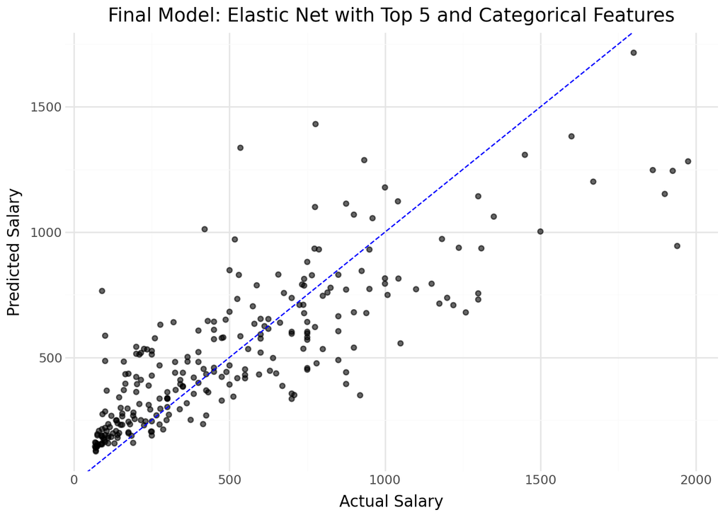

```python
# DataFrame for plotting
plot_data = pd.DataFrame({
    'actual': y,
    'predicted': y_pred
})

plot = (ggplot(plot_data, aes(x='actual', y='predicted')) +
        geom_point(alpha=0.6) +
        geom_abline(intercept=0, slope=1, color='blue', linetype='dashed') +
        labs(x='Actual Salary', y='Predicted Salary',
             title='Final Model: Elastic Net with Top 5 and Categorical Features') +
        theme_minimal())

plot
```